# Part II - (Prosper Loan DataSet Analysis)

## by (Boris MVE MANGA)

## Investigation Overview

> For the presentation, we'll start with the multivariate correlation between the features like **LoanOriginalAmount** and **MonthlyLoanPayment** and Loan **Term**. Then we'll present the correlation between **ProsperScore** and **BorrowerAPR** and the impact of Loan term. Finally We'll present the **BorrowerStatus** distribution and also the **Loan term** distribution

## Dataset Overview

> This data set contains 113,937 loans data with 81 variables on each loan, including loan amount, borrower rate, Interest rate, current loan status, borrower income, Monthly Loan Payments, Borrower State, Loan term and many other features.

## Effect of Loan Term on : **LoanOriginalAmount** VS **MonthlyLoanPayment**

> We'll present the correlation between Loan original Amount and Monthly loan Payments and the Impact of Loan Term in this correlation

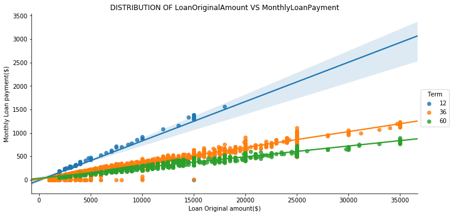

Comments: There are **3 Positives Regression Lines** for each value of **Loan Term**.

## Impact of Loan term on : **ProsperScore** VS **BorrowerAPR**

We'll present the relation between ProsperScore and BorrowerAPR and the correlation impact by Loan Term

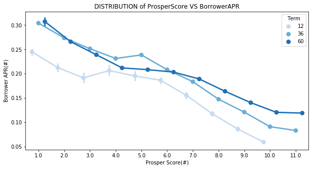

Comments : There is an impact of **Loan term** for each **negative regression** presented here.

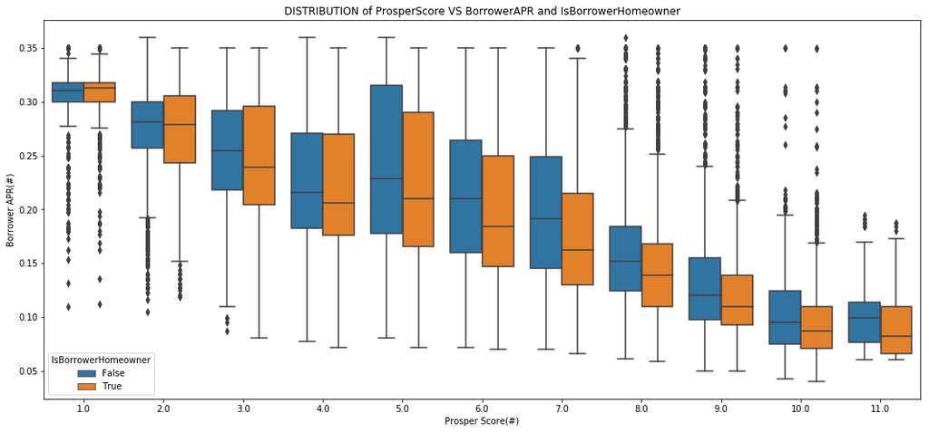

## Loan term Distribution

The distribution of Loan Term in the Dataset

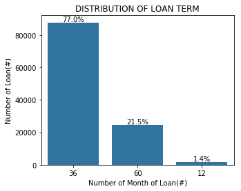

Comments : **77%** of Loan term are for **3 Years (36 months)** and **21.5%** are for **5 years(60 Months)**. Only **1.4%** are for **1 Year(12 Months)**.

## Borrower Status Distribution

We'll predent here the Borrower Status Distribution

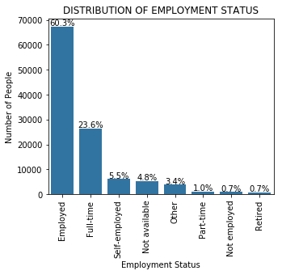

Comments : 60.3% of Borrowers are **Employed**  
**5.5%** are **Self-Employed**  
**0.7%** are **not Employed**